# CCGL9065: Our Response to Climate Change: HK2100

The (Climate) Refugee Crisis

Dr. Hongshan Guo and Class

## Last Week, in One Slide

- **The ocean is our biggest carbon-capture machine:** it took up ~29% of our CO₂ over the last decade.
- **The acceleration effect:** warming and acidification slow it down, so more of every tonne stays in the air.
- **Labels mattered:** the acidification chemistry is settled; the trawling CO₂ number is still debated.
- **Strategy #7, the Fork:** two options, both yours. Who tried it in their pitch?

This week the evidence is about people, so the labels change:  
Settled Estimate Debated Reported

[video not shown]

Tuvalu’s foreign minister gave his COP26 speech standing in the sea.

Simon Kofe, Funafuti, November 2021

Before we go any further, a question.

Should we call the people who lost their homes in the **Wang Fuk Court fire** in Tai Po

**climate refugees?**

*Hold that thought. We’ll come back to it.*

Floods, storms and rising seas already uproot tens of millions of people a year.

The ones hit first did the least to cause it —

and the law doesn’t call them refugees.

Today: who counts · what moves people · Tuvalu · Bangladesh · Venice · who caused it · Hong Kong · burden or resource? · the debate

# Part 1 · Who Counts as a Climate Refugee?

The law, the numbers, and the label.

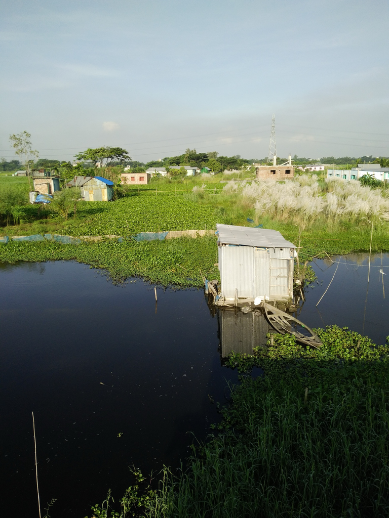

This family didn’t burn the fossil fuels. The river took their home anyway.

Flooding in Bangladesh

## The Definition Problem Settled

- The **1951 Refugee Convention** protects people fleeing **persecution** — for their race, religion, nationality, political opinion or social group.
- A flood persecutes no one. People who flee water, not war, are **not refugees** in law.
- **2020, *Teitiota v New Zealand*:** the UN Human Rights Committee upheld the deportation of a man from Kiribati — but said climate harm could one day make sending people back **unlawful**.

“Climate refugee” is a description, not a legal status.

1951 Convention relating to the Status of Refugees · UN Human Rights Committee, *Teitiota v New Zealand*, CCPR/C/127/D/2728/2016 (views published January 2020)

## The Numbers: Read the Label

**117.8 M**people forcibly displaced worldwide at the end of 2025 — mostly by war, violence and persecutionSettled

**29.9 M**times disasters forced people from their homes *inside their own country* in 2025 (45.8 M in 2024, a record)Settled

**up to 216 M**people who could move *within their own country* because of climate change by 2050 — in the worst case. Best case: 44 MEstimate

Most climate displacement never crosses a border — so refugee law wouldn’t cover it even if we rewrote it.

UNHCR, *Global Trends 2025* (June 2026) · IDMC, *Global Report on Internal Displacement 2026* · World Bank, *Groundswell Part 2* (2021): faster emission cuts and inclusive development could shrink the number by up to 80%

“216 million climate refugees by 2050.”

The number is real. The label is wrong: they are **internal migrants**, in the **worst case**.

Week 7’s lesson cuts both ways. Accurate numbers can mislead — **on our side too.**

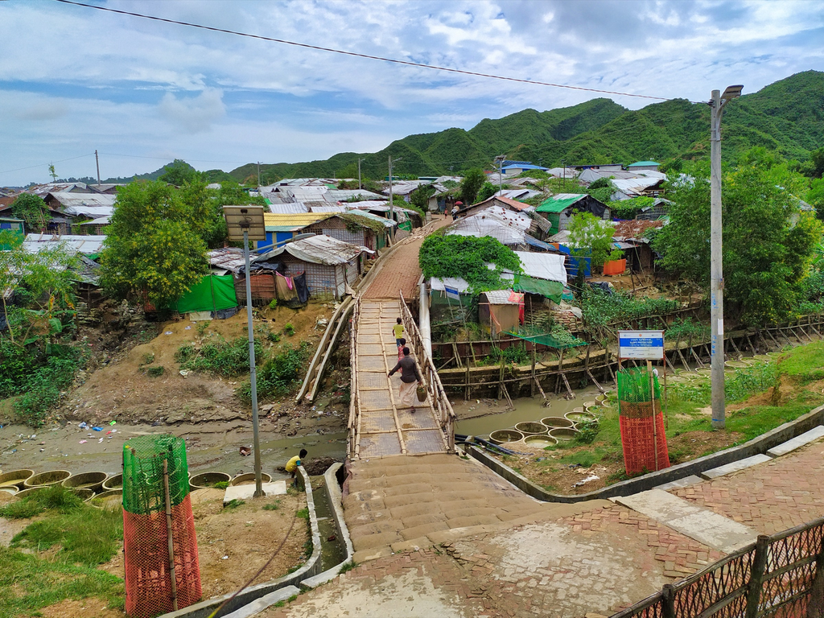

These people *are* refugees — because they fled violence, not weather.

Rohingya camps, Cox’s Bazar, Bangladesh: about 1.17 million registered refugees (UNHCR, October 2025)

## Protection Follows the Cause, Not the Need

- The Rohingya fled **persecution** in Myanmar, so the law protects them as refugees.
- Their camps sit on cleared hillsides, and **floods and landslides** hit every monsoon. In June 2025 storms damaged over 1,400 shelters across 33 camps.
- A Bangladeshi farmer whose village the river swallowed may need help just as badly — and has **no refugee status at all**.

The law asks why you left, not what you need.

UNHCR Bangladesh (2025) · UN OCHA / ECHO Daily Flash, 3 June 2025

# Part 2 · What Moves People

Slow change, sudden shocks.

## Three Forces, One Outcome

Slow

Rising seas

Atolls like Tuvalu and Kiribati sit about 2 m above the sea. Salt water reaches the wells and gardens long before it reaches the houses.

Slow

Rivers and drought

Bangladesh's rivers eat their banks: erosion displaces an estimated **50,000–200,000 people a year**. In the Sahel, harvests fail when the rains shift. Estimate

Sudden

Storms and floods

The biggest driver of disaster displacement. Typhoon Haiyan (2013) displaced **over 4 million people** in the Philippines alone.

**Old numbers travel.** “Lake Chad has shrunk by 90%” is true — of the droughts of the 1970s and 80s. Since the 2000s the lake has been stable. Check the date before you quote the number.

RMMRU, University of Dhaka and University of Sussex (2013), via Dialogue Earth · UNEP and UN OCHA on Haiyan · Pham-Duc et al. (2020), *Scientific Reports* 10, 5498

# Part 3 · Tuvalu: Planning for the Sea

10,632 people, nine atolls, and a constitution written for the worst case.

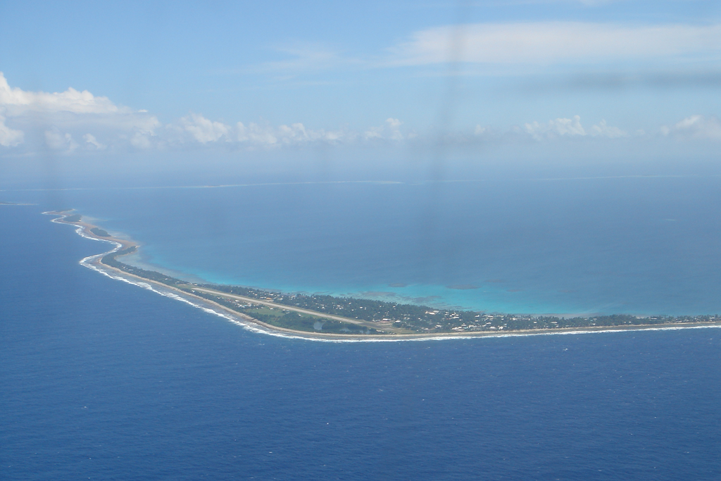

This is a country. All of it.

Funafuti Atoll, Tuvalu: the land averages about 2 m above the sea

## Tuvalu in Numbers

**10,632**people (2022 census), on nine atolls

**4.6 m**the highest point in the whole country

**+15 cm**sea-level rise in 30 years — 1.5 times the global rate

**0.00%**of all the CO₂ humanity has ever emitted

By 2050, NASA projects that **much of Tuvalu’s land** — and its critical infrastructure — will sit below the average high tide. Estimate

Tuvalu 2022 census · NASA Sea Level Change Team, Tuvalu assessment (2023) · Our World in Data / Global Carbon Budget 2025

## Tuvalu Isn’t Planning to Disappear

- **2023, a new constitution:** the State of Tuvalu continues **in perpetuity**, even if its land is lost — and its sea borders stay fixed. Settled
- **2024, the Falepili Union with Australia:** up to **280 Tuvaluans a year** can move to Australia with the right to live, work and study there. Not as refugees, but by treaty. Settled
- **The first ballot (2025)** drew about **8,750 registrations**, family members included, for 280 places. Reported
- **The price:** Australia also gained a say over Tuvalu’s security deals with other countries. Debated

A nation planning for the sea — on its own terms.

Constitution of Tuvalu Act 2023 · Falepili Union treaty (signed 2023, in force 2024) · Australian High Commission, Tuvalu (July 2025)

## But Isn’t Tuvalu Growing?

- **True:** between 1971 and 2014, Tuvalu’s land area **grew by 2.9%**. Waves piled up sand and gravel faster than the sea rose; 74% of its 101 islands got bigger. Settled
- **Also true:** a growing island can still become unlivable — salt in the wells, failing gardens, storm surges over the whole atoll.
- **The study’s own authors:** the islands will persist, *and* Tuvalu still needs to adapt.

Both facts are accurate. Quote only one and you can argue anything. **That’s Week 7’s Doubt Machine — and it works for either side.**

Kench, Ford and Owen (2018), “Patterns of island change and persistence offer alternate adaptation pathways for atoll nations”, *Nature Communications* 9, 605

# Part 4 · Bangladesh: Where Displaced People Go

The river takes the village. The city takes the people.

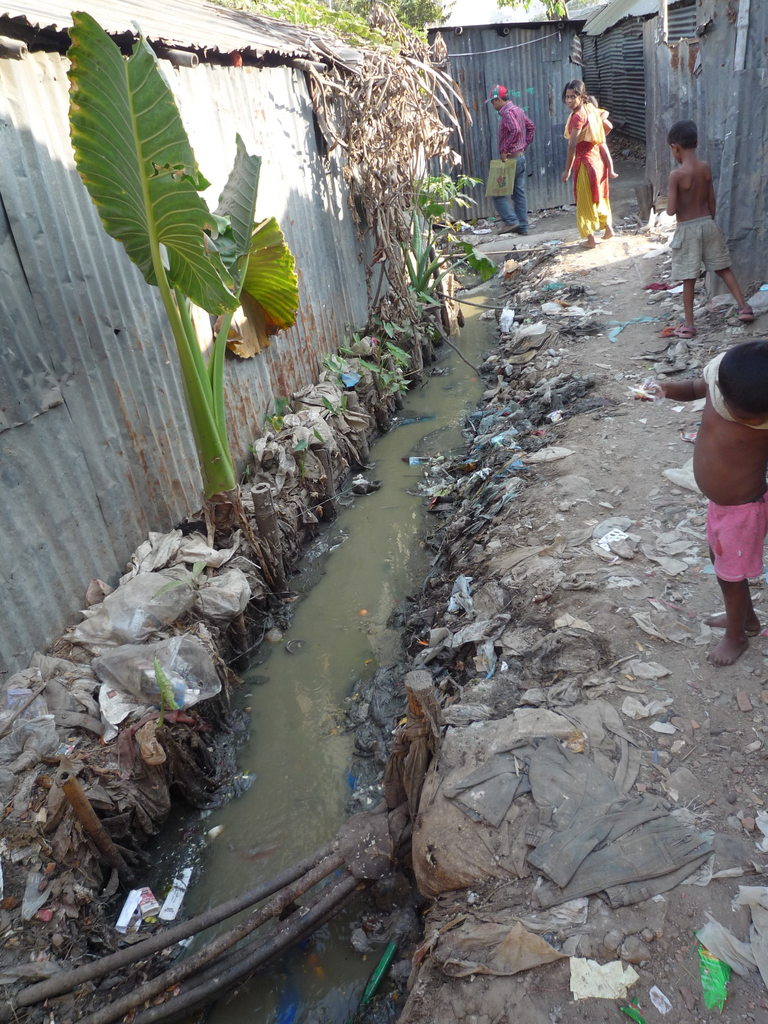

They were relocated. They were not rescued.

Boshila slum, Dhaka

## The Bangladesh Trap

- **The push:** rivers like the Padma and the Meghna eat their banks. Erosion displaces an estimated **50,000–200,000 people a year**. Estimate
- **The pull:** Dhaka. The city government estimates that **about 2,000 people a day** move into its slums — and says roughly **70%** of them are climate migrants. Estimate
- **What they find:** informal housing on flood-prone land, no secure tenure, irregular work.
- **The result:** they can’t go back — the land is gone — and they can’t get ahead.

Relocation without livelihood is not rescue. It’s warehousing.

RMMRU, University of Dhaka and University of Sussex (2013) · Dhaka North City Corporation, quoted in *Arab News* (August 2022)

Cities absorb displaced people until they can’t.

**Absorb** without **integrating** = permanent displacement.

*This is the “sponge” model. Hold onto it — the debate turns on it.*

## See It: Bangladesh’s Climate Migrants

[video not shown]

*DW Documentary (~42 min). Watch 3:00–12:00 for the river erosion and the move to Dhaka.*

# Part 5 · Same Water, Different Money

Venice and Bangladesh face the same sea.

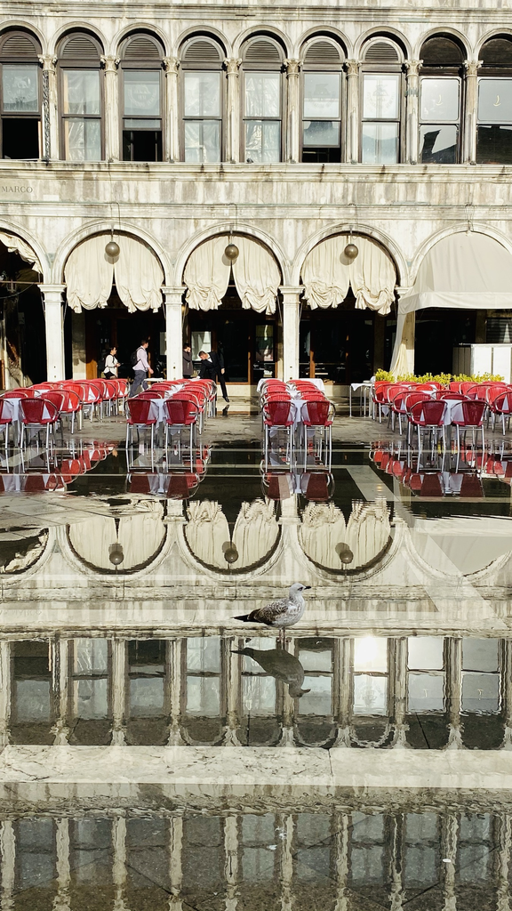

Venice floods too. Venice also built a €6 billion barrier.

## The Contrast

|  | Venice | Bangladesh |
| --- | --- | --- |
| **Response** | MOSE: 78 mobile flood gates, about €6 billion, in use since 2020 | Embankments, sandbags and shelters |
| **CO₂ per person (2024)** | Italy: **5.1 tonnes** | Bangladesh: **0.6 tonnes** |
| **Share of all CO₂ ever emitted** | Italy: **1.4%** | Bangladesh: **0.1%** |

Same water. Same physics. Different money. **That’s responsibility asymmetry.**

MOSE costs: Pagella Politica (2024); construction about €6.2 billion · CO₂: Our World in Data / Global Carbon Budget 2025

# Part 6 · Who Caused This?

Responsibility asymmetry, in one chart.

## Share of All the CO₂ Ever Emitted

United States

23.5% of CO₂

4.2% of people

European Union

16.3%

5.6%

China

15.4%

17.6%

India

3.6%

17.8%

All of Africa

2.9%

18.3%

Bangladesh

0.1%

2.1%

Share of all fossil CO₂ emitted, 1750–2024Share of the world's people, 2023

High-income countries: **17.5%** of the world’s people, **62%** of all the CO₂ ever emitted. Low-income countries: **9%** of the people, **0.6%**.

Our World in Data, from the Global Carbon Budget 2025 (fossil CO₂, excluding land use) and UN population estimates · World Bank income groups

## Closer to Home

**7.4 M**people in Hong Kong

**0.09%**Hong Kong's share of all the CO₂ ever emitted

**171 M**people in Bangladesh

**0.11%**Bangladesh's share of all the CO₂ ever emitted

Nearly the same total — from **one twenty-third** as many people. Per person today: Hong Kong **4.5 tonnes** a year, Bangladesh **0.6**.

Responsibility asymmetry isn’t only about America and Europe. It includes us.

Our World in Data / Global Carbon Budget 2025: territorial fossil CO₂ (imported goods are not counted) · population 2023

## The Policy Gap

- **Refugee law:** the 1951 Convention doesn’t cover climate displacement. Settled
- **The Paris Agreement** mentions **migrants once**, in its preamble. A separate decision set up a Task Force on Displacement — it advises; it cannot oblige. Settled
- **Money:** the new Loss and Damage Fund’s first call offered **US$250 million**. Countries asked for about **US$3 billion**. Reported
- **Bilateral deals** like Australia–Tuvalu are the exception, not the rule.

We have a system for people fleeing war. We have none for people fleeing water.

Paris Agreement (2015), preamble · UNFCCC decision 1/CP.21, paras 49–50 · Fund for responding to Loss and Damage, Barbados Implementation Modalities (2025); *Eco-Business* (2026)

# Part 7 · Back to Hong Kong

A host city, a coastline — and a hard question.

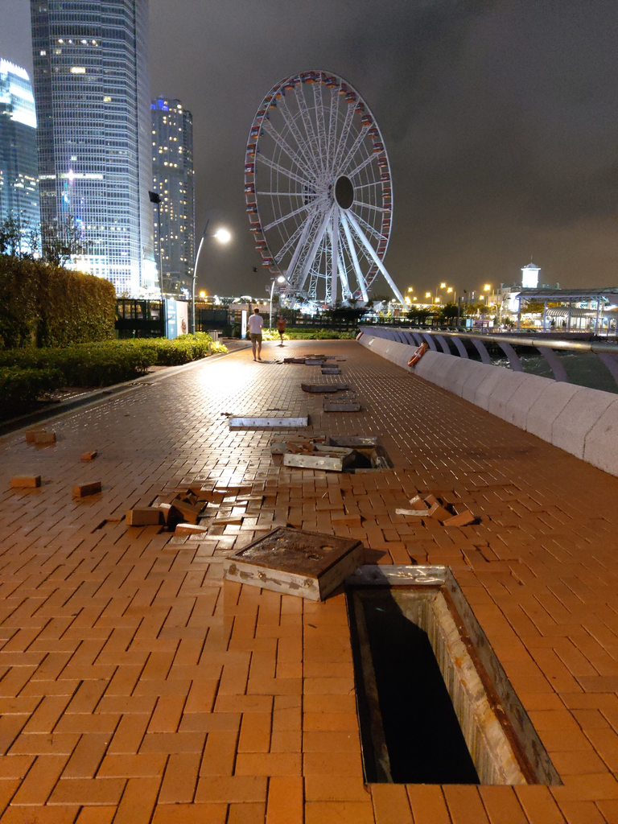

This happened here. Mangkhut was a preview.

Central Harbourfront after Super Typhoon Mangkhut, September 2018

## Hong Kong’s Own Exposure

- **Storms:** Mangkhut (2018) brought Signal No. 10 and a storm surge that flooded low-lying coastal areas.
- **Rain and drought:** the Observatory projects **more extremely wet *and* more extremely dry years** this century. The driest year on record was **1963** — when taps ran **four hours every four days**. Settled
- **Asylum:** Hong Kong never signed the 1951 Convention. Since 2009 it has decided about **34,800** protection claims and accepted **390** — about 1 in 90. Even an accepted claim brings no right to settle. Settled
- **Inequality:** **23.6%** of people were below the poverty line before government transfers (2020, the latest report); 7.9% after.

Hong Kong Observatory, projections of extremely wet and dry years (2026) · Water Supplies Department · Immigration Department, as at 30 September 2026 · Hong Kong Poverty Situation Report 2020

## The Tai Po Question: What We Know

- **26 November 2025:** fire swept through seven of the eight towers at Wang Fuk Court. **168 people died**; over 4,000 residents lost their homes. Settled
- **The weather:** a red fire danger warning had been in force for two days; the air was dry, with humidity around 40%. Settled
- **The spread:** the inquiry heard that the fire most likely began with cigarettes in a light well, and spread through scaffolding netting that failed fire-retardancy tests and foam boards over the windows. The fire alarms did not work properly. Reported
- **Accountability:** seven people and two companies face charges, including manslaughter. The inquiry’s report, submitted in October 2026, reportedly names four government bodies. Reported
- **Did climate change make that dry spell more likely?** No study has tested it. Not established

Independent committee hearings (2026), reported by AP, SCMP and *The Standard* · Hong Kong Observatory warnings, 24–26 November 2025

## Where Do You Draw the Line?

**If yes:** Hong Kong isn’t only a possible *host* for climate refugees. It is already *producing* them.

**If no:** how direct does the climate link have to be?

- A Bangladeshi farmer whose field the river ate?
- A Sahel farmer whose rains failed?
- A Tai Po family whose building burned under a red fire danger warning?

Week 3 again: where you draw the boundary decides whose problem it is.

And Week 7’s warning: calling it a “climate” disaster uses a true fact — it was dry — and can pull attention away from the people and agencies whose failures the inquiry examined.

## The Human Story: The Carteret Islands

- Off Bougainville, Papua New Guinea, king tides and storm surges salted the islanders’ wells and gardens.
- They are often called the world’s first climate refugees — **a label they reject.**
- Since 2006 their own organisation, **Tulele Peisa** (“sailing the waves on our own”), has moved families to mainland Bougainville, with little government money.

**PRO-CLIMATE says:** “They did nothing to cause this — and they had to organise their own rescue.”

**PRO-DEVELOPMENT says:** “Moving a few thousand islanders is possible. Moving tens of millions is not. Help people stay.”

**The real question:** who decides who moves — and who pays?

Tulele Peisa; JRS Australia (2012); Pacific Islands News Association reporting

# Part 8 · Burden or Resource?

Everything so far treats displaced people as a problem to manage.

What if displaced people are not a **burden** to manage —

but a **resource** to build with?

## The Case You Already Live In: Hong Kong

- **1945:** about **600,000** people. **Mid-1950:** about **2.2 million**, after waves of arrivals from the mainland. Settled
- More than **30 Shanghai cotton-spinning firms** arrived with machinery, capital and managers — the start of Hong Kong’s textile boom.
- Many others arrived with nothing, and farmed in the New Territories or worked in the new factories.

**You are sitting in a city built by refugees.**

**But be honest about the conditions:** many arrivals shared a language and culture with Hong Kong, and some brought capital. A farmer arriving in Dhaka with nothing faces a different city. **The success wasn’t automatic — the conditions mattered.**

*Hong Kong Yearbook*; Hong Kong Memory, “Industrialisation in post-war Hong Kong”

## Refugees as Resources: The Evidence (and Its Limits)

| Approach | The claim | The complication |
| --- | --- | --- |
| **Right to work** (Uganda) | Land, jobs and freedom of movement for **1.9 million** refugees — Africa’s largest refugee population | The 2025 appeal was only **18%** funded by August, and food rations were cut |
| **Labour integration** (Germany) | Of those who arrived in 2015, **64%** were in work by 2022 — 75% of men, 31% of women | The politics: the anti-immigration AfD came **second** in the 2025 election |
| **Private sponsorship** (Canada) | Citizens’ groups have sponsored more than **327,000** refugees since 1979 | Scales slowly, and depends on volunteers’ time and money |

None of these is a clean success story. All of them beat warehousing.

WFP Uganda country brief (September 2025) · IAB, Institute for Employment Research (2024) · UNHCR Canada

## The Real Choice

Two models. Same displaced people. Neither is perfect.

**Model A: Suppress** (the sponge model)

- No legal status → no work → no integration → permanent dependency → backlash

**Model B: Leverage** (imperfect, costly, politically risky)

- Right to work → contribution → tension *and* benefit → slow, messy integration

Model B is harder, more expensive and politically dangerous — Germany shows that. Model A produces slums and dependency, and the backlash comes anyway, just later.

So the debate isn’t only “move or stay?” It’s: if people do move, what system are we building for them?

# Part 9 · The Debate

Help people stay — or help them move?

## Two Sides. Two Responses to Displacement.

PRO-CLIMATE

= Open doors, shared responsibility

= “We caused this — we must help”

High-income countries emitted 62% of all the CO₂ ever released

PRO-DEVELOPMENT

= Invest in resilience where people live

= “Help people stay first”

Adaptation can return $2–10 for every $1 invested

Our World in Data / Global Carbon Budget 2025 · Global Commission on Adaptation, *Adapt Now* (2019)

## The Core Tension

| PRO-CLIMATE | PRO-DEVELOPMENT |
| --- | --- |
| Owe — rich nations caused most of the warming | Stay — most climate migrants never leave their own country |
| Open legal routes, like Australia–Tuvalu | Invest where people live — adaptation pays $2–10 per $1 |
| Integrate — 64% of Germany’s 2015 arrivals were in work by 2022 | Protect social stability — backlash is real |
| Some places can’t be saved in place | Most places can, if we pay for it |

Both are true. The debate is about **where the next dollar goes.**

## Why This Motion?

This debate connects lived reality to a global policy question:

The Moral Case

Tuvalu emitted almost nothing, and by 2050 much of its land may sit below the high tide. When the land goes, “adapt at home” stops being an option. **Who owes them a way out?**

The Pragmatic Case

Most climate migrants never cross a border, and most people would rather stay. Adaptation money reaches far more people than visas do. **But Dhaka shows what moving without a plan does.**

The Hong Kong Question

Hong Kong has accepted 390 of about 34,800 protection claims since 2009 — and it was built by refugees. **Could it ever host climate migrants? Should it?**

## This Week’s Debate Motion

**“This house believes that international climate funding should help communities stay rather than help people move — even in places the sea may eventually claim.”**

PRO-CLIMATE · against  
You can’t sandbag an atoll forever. The countries that caused the warming owe people a safe way out — and Germany and Canada show that integration can work.

PRO-DEVELOPMENT · for  
Most people want to stay, most moves happen inside a country, and adaptation pays $2–10 per $1. Dhaka shows what moving without a plan does.

Both sides have real evidence. Label yours: Settled Estimate Debated Reported

# Role-Play: The Refugee Debate

# Group Assignment Time!

## Presentation Countdown

05:00

## The Debate

You will take **stakeholder positions**: Climate Refugee, Host City Official, UNHCR Representative, National Government Minister, NGO Aid Worker, Local Resident of a Host Community.

**Think across scales:**

- **The person** — what does displacement feel like? What do you need?
- **The city** — Dhaka, Hong Kong, Lagos. What would 2,000 arrivals a day do to yours?
- **The system** — who pays? Who decides? What framework would actually work?

The strongest debaters make the abstract **personal** and the personal **structural** — and label their evidence.

## Ground Rules

- This is a **safe space** for exploration and discussion. There are **no wrong answers**, only opportunities to learn.
- **Respect** and **open-mindedness** are our guiding principles. Every opinion shared contributes to collective learning.
- **Feedback** and **reflection** are encouraged. This is a chance to voice thoughts, ask questions, and grow from the experience.

## Pro-Climate Talking Points

**Shared responsibility — and safe ways out:**

- **Who caused it** — high-income countries: 17.5% of the world’s people, 62% of all the CO₂ ever emitted Settled
- **Some places can’t be saved in place** — NASA projects much of Tuvalu’s land below the average high tide by 2050 Estimate
- **Legal routes work** — up to 280 Tuvaluans a year now move to Australia by treaty, with the right to live and work there Settled
- **Integration pays off, slowly** — 64% of Germany’s 2015 arrivals were in work by 2022; Canadians have sponsored 327,000 refugees since 1979

## Pro-Development Talking Points

**Help people stay — and move only with a plan:**

- **Most moves are internal** — up to 216 million people could move within their own countries by 2050; visas abroad would reach few of them Estimate
- **Adaptation pays** — $1.8 trillion invested could return $7.1 trillion in net benefits (Global Commission on Adaptation) Estimate
- **Absorption without integration fails** — about 2,000 people a day move into Dhaka’s slums, and the city can’t keep up Estimate
- **Hosting is hard** — Uganda’s refugee programme was only 18% funded in 2025, and the AfD came second in Germany’s election Settled

# This Week’s Conceptual Takeaway

## Remember Week 3? System Boundaries.

In Week 3 you learned that **where you draw the boundary changes who looks responsible.** The same principle explains why the “sponge” model fails:

Boundary: The Person

It’s a **shelter** problem. Give them a tent. Feed them. Move on.

*The emergency response.*

Boundary: The City

It’s an **absorption** problem. Dhaka takes in about 2,000 people a day. Build more. Manage the flow.

*The “sponge” model.*

Boundary: The System

It’s a **responsibility** problem. Who emitted the CO₂ that raised the sea? Who profits from inaction? Who should pay?

*Where the real debate begins.*

## Why the Sponge Model Fails

The sponge model treats displacement as **logistics** instead of **systemic failure.**

- **It ignores the cause.** Moving people from flooded village A to crowded city B doesn’t address why A flooded.
- **It ignores livelihood.** Relocation without work, sanitation and integration creates permanent dependency, not recovery.
- **It ignores the cascade.** Displacement doesn’t end when people arrive. It *triggers* the next crisis: urban strain → competition for jobs and housing → political backlash → more displacement.

Displacement is not a destination. It’s the **middle** of a chain — and next week, we follow that chain.

## Responsibility Asymmetry

Now you know:

- Floods and storms forced people from their homes **29.9 million times** in 2025 — and the law calls none of them refugees
- **Tuvalu** has rewritten its constitution so the nation can outlive its land
- **Venice** built a €6 billion barrier; **Bangladesh**, with 0.1% of all CO₂ ever emitted, builds embankments
- **High-income countries** emitted 62% of all the CO₂ ever released; the poorest countries, 0.6%
- And the “sponge” model — absorb, don’t integrate — is already failing

**Your portable takeaway:** When someone says “climate refugees,” ask three questions: *whose boundary are you drawing?* *What cascade does it trigger?* And: *are you designing a system that suppresses — or one that leverages?*

## The Semester So Far

WEEK 1Spectacle Formula

Fact + human story + stakes. Data alone doesn't persuade.

WEEK 2Complexity

Rarely one right answer — that's not a bug, it's the point.

WEEK 3System Boundaries

Where you draw the boundary changes the answer.

WEEK 4Timing

When energy flows matters as much as how much.

WEEK 5Built Environment

Buildings are climate decisions. Hot cities heat themselves.

WEEK 6Structural Incentives

Every player acts rationally — the outcome is catastrophic.

WEEK 7The Doubt Machine

Accurate, nuanced facts can still be arranged to mislead.

WEEK 8Invisible Infrastructure

The ocean sink is slowing — the climate can speed itself up.

WEEK 9Responsibility Asymmetry

Those hit first did least to cause it — and the law doesn't see them.

Still to come: Week 10 Cascade Effects · Week 11 Perspective

## Two Threads That Run to Week 11

1 · Accurate facts can still mislead

**Week 7**Correct, nuanced details arranged to manufacture doubt

→

**Week 8**Label every claim: settled, emerging or debated

→

**Today**"216 million climate refugees": a real number with the wrong label

→

**Week 11**No framing is neutral — not even yours

2 · The climate can speed itself up

**Week 8**A warmer ocean absorbs less CO₂, which warms it more

→

**Today**Displacement triggers the next crisis: strain, backlash, more displacement

→

**Week 10**Ice, permafrost, tipping points: loops that feed themselves

→

**Week 11**A cascade in orbit: space debris

Next week, the chain becomes a cascade.

# The Persuasion Playbook | Strategy #8

## The Invisible Bandwagon

A UK tax office added one line to its reminder letters:

*“9 out of 10 people in Exeter pay their tax on time.”*

In that first trial, on-time payment rose by **15 percentage points.**

Not moral appeal. Not threats. Just: *you’re the odd one out.*

Behavioural Insights Team (2012), *Applying behavioural insight to reduce fraud, error and debt*. A larger national trial later found smaller but real effects: Hallsworth et al. (2017), *Journal of Public Economics* 148

## The Science

This is **social proof** plus **normative messaging**.

But the key is: **local and specific**.

- “Most people” → weak
- “Most people in your building” → strong
- “Most people in your building with kids your age” → irresistible

**The more similar the reference group, the stronger the pull.**

## You Just Saw It

The strongest arguments today won’t say “people care about climate.”

They’ll say something like:

*“Most engineering students at HKU already think about flood risk in their design projects.”*

A bandwagon that didn’t exist until you named it — so make sure yours is true.

## Next Week’s Challenge

**Create a bandwagon for your argument.**

Make it local. Make it specific. Make them the outlier if they disagree.

## Next Week: Cascade Effects

Next week, we watch a system **cascade.**

One change triggers another, which triggers another. Permafrost thaws into methane. Ice gives way to dark water that absorbs more heat. Some changes can be walked back; some are one-way doors.

**Cascade effects and tipping points:** small changes, outsized consequences.

## Logistics: Final Assessment Items — Quick Q&A

**Q: What topic should I pick?** Within or outside of in-lecture ones? Consistent theme across all three items? **A:** Up to you.

**Q: What should the final reflection paper be about?** **A:** What you think should be **our response to Climate Change at Hong Kong for 2100.**

**Q: Can we see collage/video examples?** **A:** Refer to the ‘Roadmap’ document.

**Q: How do I make videos?** **A:** Script matters more than production quality. Voice-over on still images works. Clips stitched with slogans works.

## Further Reading and Sources

UNHCR (2026). *Global Trends: Forced Displacement in 2025*. IDMC (2026). *Global Report on Internal Displacement 2026*; IDMC (2025), *GRID 2025*.

Clement, V. et al. (2021). *Groundswell Part 2: Acting on Internal Climate Migration*. World Bank.

UN Human Rights Committee (2020). *Teitiota v New Zealand*, CCPR/C/127/D/2728/2016. Convention relating to the Status of Refugees (1951).

UNFCCC (2015). Paris Agreement, preamble; decision 1/CP.21, paras 49–50 (Task Force on Displacement). Fund for responding to Loss and Damage, Barbados Implementation Modalities (2025); *Eco-Business* (2026) on the funding gap.

Kench, P. S., Ford, M. R. & Owen, S. D. (2018). Patterns of island change and persistence offer alternate adaptation pathways for atoll nations. *Nature Communications* 9, 605.

NASA Sea Level Change Team (2023). Tuvalu sea-level assessment. Constitution of Tuvalu Act 2023. Falepili Union treaty (2023); Australian High Commission, Tuvalu (2025).

RMMRU, University of Dhaka & University of Sussex (2013), river-erosion displacement estimate. Dhaka North City Corporation, quoted in *Arab News* (2022). UNHCR Bangladesh (2025); UN OCHA / ECHO (June 2025).

Pham-Duc, B. et al. (2020). The Lake Chad hydrology under current climate change. *Scientific Reports* 10, 5498. UNEP and UN OCHA on Typhoon Haiyan (2013).

Our World in Data, from the Global Carbon Budget 2025 and UN population estimates: cumulative and per-capita CO₂. Pagella Politica (2024) on MOSE costs.

Hong Kong Observatory (2026), projections of extremely wet and dry years. Water Supplies Department (1963 rationing). Immigration Department, non-refoulement statistics (30 September 2026). *Hong Kong Poverty Situation Report 2020*.

Wang Fuk Court fire: independent committee hearings (2026), reported by AP, SCMP and *The Standard*.

*Hong Kong Yearbook*; Hong Kong Memory. WFP Uganda (2025). IAB (2024), refugees’ employment in Germany. UNHCR Canada, private sponsorship. Tulele Peisa; JRS Australia (2012).

Global Commission on Adaptation (2019). *Adapt Now*. Behavioural Insights Team (2012); Hallsworth, M. et al. (2017), *Journal of Public Economics* 148.